# NAPED — Portfólio de Ações | Janeiro 2026

[figure not shown]

Afya São João del Rei

Portfólio de Ações  
NAPED

Janeiro de 2026

Mês de preparar o setor para receber nossos professores e iniciarmos o novo ano.

Ação 1Janeiro 2026

Reunião Pró-Reitora Acadêmica, NAPED e NED

Alinhamento Institucional

Para iniciar o semestre, foi realizada uma reunião com Elihege, coordenadora do NED, e com a Pró-Reitora Acadêmica, Kelly Torres, com o objetivo de alinhar o diálogo entre os setores ao longo do semestre.

Reuniões quinzenais agendadas; ações entre NAPED e NED alinhadas conforme Diretrizes Nacionais.

Medicina

Evidências

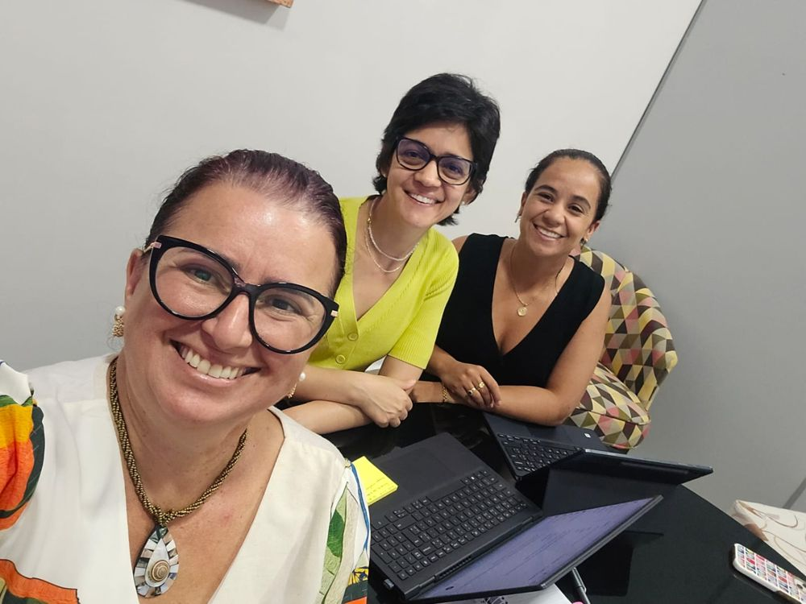

Reunião NED, NAPED e Pró-Reitoria Acadêmica

Primeiro encontro de alinhamento entre NED, NAPED e Pró-Reitoria Acadêmica.

Ação 2Janeiro 2026

Encontro de Desdobramento de Metas

Planejamento Estratégico 2026

Momento dedicado a planejar e desdobrar as metas a serem alcançadas ao longo de 2026, reunindo a Reitoria, colaboradores administrativos e coordenadores de curso para a construção coletiva dos objetivos institucionais do ano.

Metas traçadas em conjunto com a Reitoria, colaboradores administrativos e coordenadores de curso.

Evidências

[figure not shown]

Desdobramento de Metas

Reunião de desdobramento de metas com participação da Reitoria, colaboradores administrativos e coordenadores de curso.

[figure not shown]

Desdobramento de Metas

Reunião de desdobramento de metas com participação da Reitoria, colaboradores administrativos e coordenadores de curso.

[figure not shown]

Desdobramento de Metas

Reunião de desdobramento de metas com participação da Reitoria, colaboradores administrativos e coordenadores de curso.

Ação 3Janeiro 2026

Cerimônia do Jaleco de Medicina

Acolhimento dos Calouros 2026.1

Cerimônia do jaleco do curso de Medicina para os calouros da turma 2026.1, marcando simbolicamente o início da trajetória acadêmica na formação médica.

Momento simbólico de acolhimento e compromisso com a formação médica.

Medicina

Evidências

[figure not shown]

Cerimônia do Jaleco da Medicina

Apresentação da cerimônia do jaleco — MED XXI.

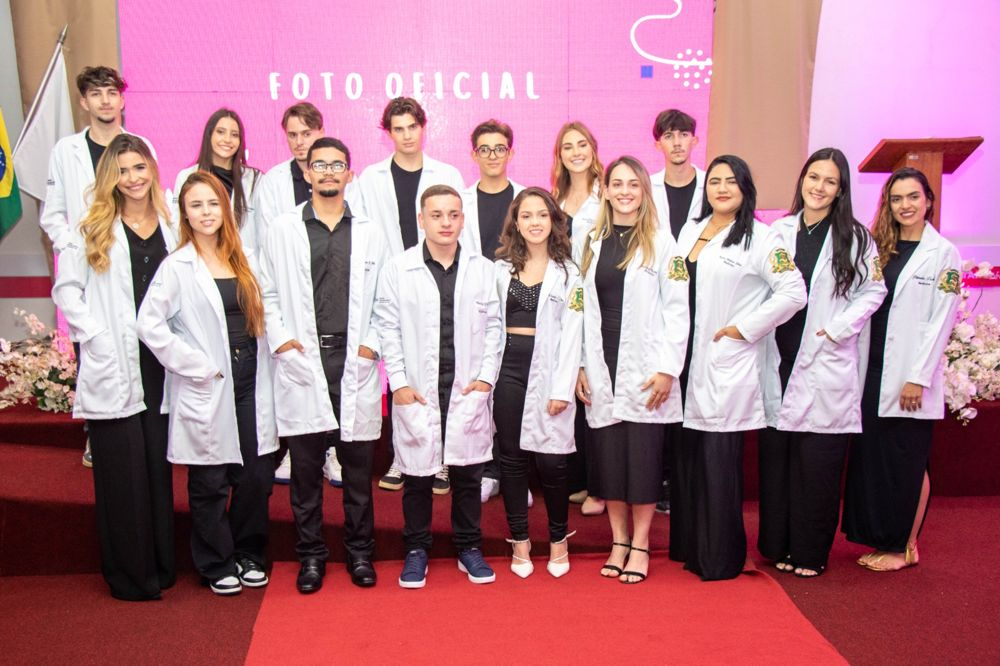

Turma 2026.1

Foto oficial da turma 2026.1 de Medicina.

Ação 4Janeiro 2026

Pílulas de Afeto

Cuidado e Humanização Institucional

Ação que consistiu na preparação e distribuição de pílulas com mensagens poéticas e espirituais, voltadas ao acolhimento e à sensibilização da comunidade acadêmica ao longo do semestre.

Ação simbólica de cuidado, escuta e humanização no ambiente institucional.

Evidências

[figure not shown]

Pílulas com mensagens poéticas e espirituais

Pílulas prontinhas para serem compartilhadas e lidas no decorrer do semestre.

[figure not shown]

Preparação das pílulas com mensagens — registro 1

Registro do processo de preparo das pílulas com mensagens poéticas e espirituais.

[figure not shown]

Navegar pelo portfólio